# iLykei Lecture Series Machine Learning Random Forest and Boosting Workshop

Y.Balasanov, L.Nazarov, © iLykei 2016-2021

# 1 Review of bagging, random forests and boosting

## 1.1 Bagging

Leo Breiman in Technical Report No. 421 (1994) [Bagging Predictors](https://www.cs.princeton.edu/courses/archive/fall08/cos402/readings/bagging.pdf) proposed to improve the decision trees performance by combining results of several trees built on randomly generated training subsets.  
This method was called Bagging (Bootstrap AGGregating).

Denote

- $X$ - set of objects;
- $Y$ - either finite set of classes (classification) or set of real numbers (regression);
- $f: X\rightarrow Y$;
- $L = {(x_1,f(x_1)),..,(x_m,f(x_n))}$ - learning sample;
- $B^p = \{ L_1,...,L_p \}.$ - set of new learning samples each of size $n$, drawn from $L$ by sampling uniformly and with replacement.

Each learning sample $L_i$ generates predictor (tree) $\widehat{f}_i$. In case of regression simple averaging gives aggregated predictor
$$\widehat{f}(x)=\frac{1}{p}\sum_{i=1}^{p}\widehat{f}_{i}(x).$$
A popular method of aggregating for classification problem is majority voting. Let
$$N_{y}(x)=\sum_{i=1}^{p}I_{\left( \widehat{f}_{i}(x)=y\right) },$$
where $I_A$ is the indicator of set $A$. The formula for aggregating predictor is
$$\widehat{f}(x)= \underset{y\in Y}{\operatorname{argmax}}N_{y}(x).$$
This bootstrapping procedure leads to better model performance because it decreases the variance of the model, without increasing the bias.
This means that while the predictions of a single tree are highly sensitive to noise in its training set, the average of many trees is not, as long as the trees are not correlated.
But if one or a few features happen to be very strong predictors for the response variable, these features will be selected in many of the trees, causing them to become correlated. Random forest method can overcome this disadvantage.

## 1.2 Random Forests

Random Forest is a machine learning method capable of performing both regression and classification tasks.

It also can be used as dimensionality reduction method.

Random forests can deal with missing values, outlier values.  
However, implementation in library `randomForest` does not allow missing values.  
Another package `randomForestSRC` can be used instead.  
See [discussion on missing values in random forests](https://stats.stackexchange.com/questions/98953/why-doesnt-random-forest-handle-missing-values-in-predictors) for more details.

Random forests provide an improvement over bagged trees by decorrelating trees when the impose constraints on predictors.

As in bagging, a number of decision trees is built on bootstrapped learning samples.  
But when building these decision trees, each time a split in a tree is considered, a random sample of $m$ predictors is chosen as split candidates from the full set of $M$ predictors.  
The split is allowed to use only one of those $m$ predictors.  
Here is more detailed description of the algorithm.

1. Assume that the size of the learning set $L$ is $n$ as above.  
   Then, bootstrapped sample is generated from $L$ by sampling uniformly and with replacement.  
   This sample will be the training set for the tree.
2. If there are $M$ input variables, a number $m<M$ is specified such that at each node, $m$ variables are selected randomly out of $M$.  
   The best split on these $m$ is used to split the node.  
   The value of $m$ is held constant through the process of growing the forest.
3. Algorithm builds $N_{tree}$ trees. Each of them is grown to the largest extent possible and there is no pruning.
4. Predict new data by aggregating the predictions of the $N_{tree}$ trees (i.e., majority votes for classification, average for regression).

The value of $m$ is taken small compare to $M$. The inventors make the following recommendations:

- For classification, the default value for $m$ is $\sqrt{M}$ and the minimum node size is one.
- For regression, the default value for $m$ is $M/3$ and the minimum node size is five.

In practice the best values for these parameters will depend on the problem, and they should be treated as tuning parameters.

Random forest can handle large data set with higher dimensionality. It can handle thousands of input variables and identify most significant variables so it is considered as one of the dimensionality reduction methods. Further, the model outputs Importance of variable, which can be a very handy feature.

It has an effective method for estimating missing data and maintains accuracy when a large proportion of the data are missing. It has methods for balancing errors in data sets where classes are imbalanced.

Random Forest is better at classification but not as good for regression problems since it does not give continuous output.

It looks like a black box approach to statistical modelers - you have very little control on what the model does.  
You can at best - try different parameters and random seeds.

## 1.3 Boosting

The term "Boosting" refers to a family of algorithms which converts group of weak learners to a strong learner(s).  
Boosting was originally designed for classification problems, but it was later extended to regression.  
Like bagging, boosting is a general approach that can be applied to many statistical learning methods for regression or classification.

### 1.3.1 Gradient boosting trees

Cheng Li presentation [A Gentle Introduction to Gradient Boosting](http://www.ccs.neu.edu/home/vip/teach/MLcourse/4_boosting/slides/gradient_boosting.pdf) is partially used in this section.

In each step of Boosting procedure the tree is fitted to the residuals $r_x = f(x) -\widehat{f}(x)$ of the previous step.
One may note that residual is the negative derivative of the square loss function:
$$\frac{\partial }{\partial \widehat{f}(x)}L\left( f(x),\widehat{f}(x)\right)$$
where $L(u,v)=\frac{1}{2}(u-v)^{2}$ is the loss function.
So, boosting can be considered as a gradient descent algorithm.

A generic gradient boosting method for smooth loss function $L$ is described by [Friedman, J. H. Greedy Function Approximation: A Gradient Boosting Machine.](http://statweb.stanford.edu/~jhf/ftp/trebst.pdf)

# 2 Simple Example with Clustering

Consider a simple example in which a sine wave signal covered by some noise is analyzed using gradient boosting method.

Simulate the data.

```r
set.seed(1180)
x<-seq(0,2*pi,by=.01)
sigmaEps<-.1
eps<-rnorm(length(x),0,sigmaEps)
signal<-sin(x)+eps
data<-data.frame(x=x,signal=signal)
head(data)
```

```
##      x      signal
## 1 0.00  0.15737361
## 2 0.01 -0.16510747
## 3 0.02 -0.04831630
## 4 0.03  0.06957697
## 5 0.04 -0.02137105
## 6 0.05  0.11559686
```

Create a function which makes a plot of the first and the last columns of a data frame.

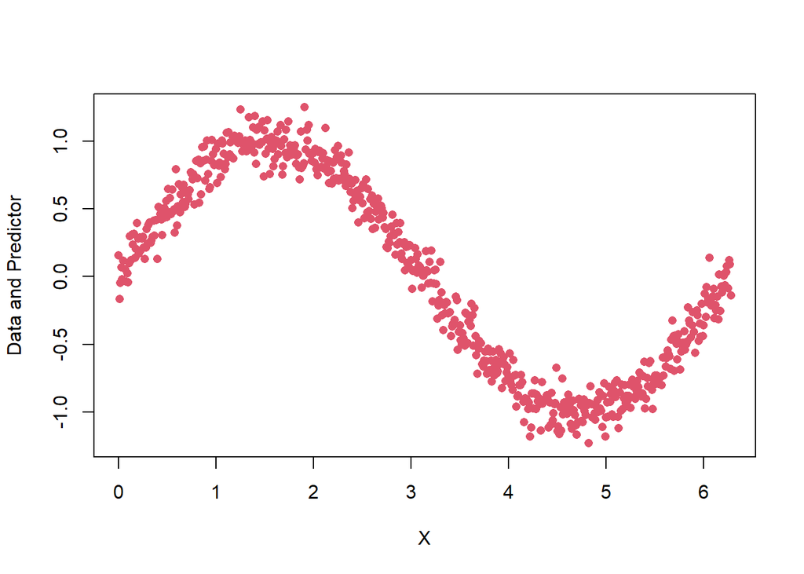

```r
myPlot<-function(myDataFrame){
  lastCol<-ncol(myDataFrame)
  matplot(myDataFrame$x,myDataFrame[,c(2,lastCol)],pch=16,xlab="X",ylab="Data and Predictor")
}
myPlot(data)
```

Make a simple learner that uses cluster analysis to break the sample into 2 clusters.

```r
library(mclust)
```

```r
model<-Mclust(data$signal,G=2)
```

Explore the returned object.

```r
summary(model)
```

```
## ----------------------------------------------------
## Gaussian finite mixture model fitted by EM algorithm
## ----------------------------------------------------
##
## Mclust E (univariate, equal variance) model with 2 components:
##
##  log-likelihood   n df       BIC       ICL
##       -583.6187 629  4 -1193.014 -1251.347
##
## Clustering table:
##   1   2
## 306 323
```

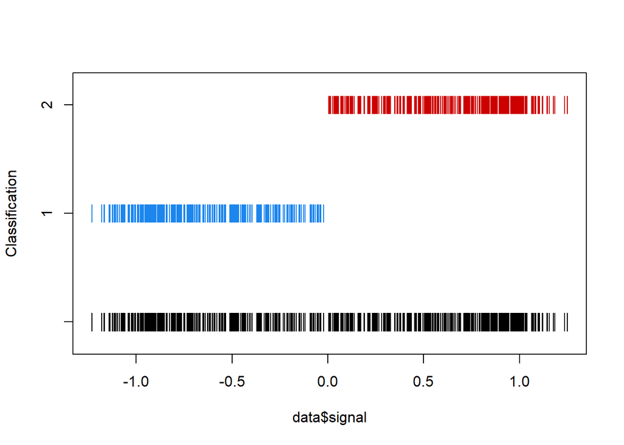

```r
plot(model, what="classification")
```

```r
names(model)
```

```
##  [1] "call"           "data"           "modelName"      "n"
##  [5] "d"              "G"              "BIC"            "loglik"
##  [9] "df"             "bic"            "icl"            "hypvol"
## [13] "parameters"     "z"              "classification" "uncertainty"
```

```r
model$parameters
```

```
## $pro
## [1] 0.4901664 0.5098336
##
## $mean
##          1          2
## -0.6454830  0.6191915
##
## $variance
## $variance$modelName
## [1] "E"
##
## $variance$d
## [1] 1
##
## $variance$G
## [1] 2
##
## $variance$sigmasq
## [1] 0.1136167
```

```r
head(model$classification)
```

```
## [1] 2 1 1 2 1 2
```

Clustering identified two groups with positive and negative mean values and the same standard deviation.

Create the first learner, find fitted values and add the column of them to the data frame.  
Plot it.

```r
data$learner1<-model$parameters$mean[model$classification]
head(data)
```

```
##      x      signal   learner1
## 1 0.00  0.15737361  0.6191915
## 2 0.01 -0.16510747 -0.6454830
## 3 0.02 -0.04831630 -0.6454830
## 4 0.03  0.06957697  0.6191915
## 5 0.04 -0.02137105 -0.6454830
## 6 0.05  0.11559686  0.6191915
```

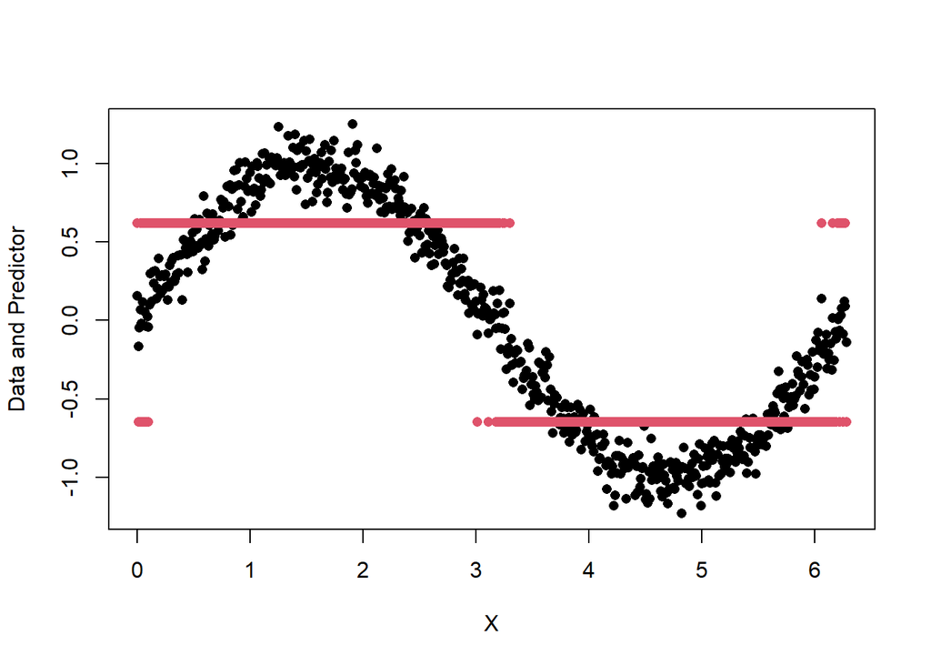

```r
myPlot(data)
```

The plot shows the original signal plus noise data (black) and the prediction by the first learner (red).

Obviously, the learner is too simplistic to capture the nonlinear pattern of the signal, but it does separate the positive and the negative clusters of points.

Extract residuals after the first learner.

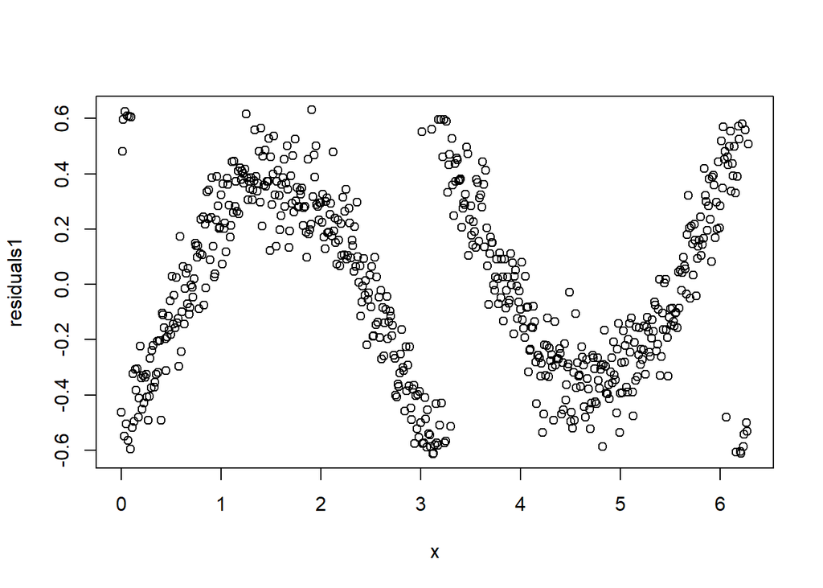

```r
residuals1<-data$signal-data$learner1
plot(x,residuals1)
```

```r
(sd1<-sd(residuals1))
```

```
## [1] 0.3199656
```

```r
c(sd(data$signal),sd1)
```

```
## [1] 0.7170284 0.3199656
```

There is a remaining pattern in the residuals, but we observe a significant reduction in standard deviation relative to the original data.  
In order to repeat the steps of gradient boosting several more times create a function `simpleLearner<-function(mySignal)` which takes a signal vector and splits it into 2 groups using `Mclust()`, returning vector of the next learner predicted values.

(Skipped Code)

Create the vector of fitted values corresponding to the second learner, add fitted values of learner 1 with fitted values of learner 2 and make a new column in the data frame.

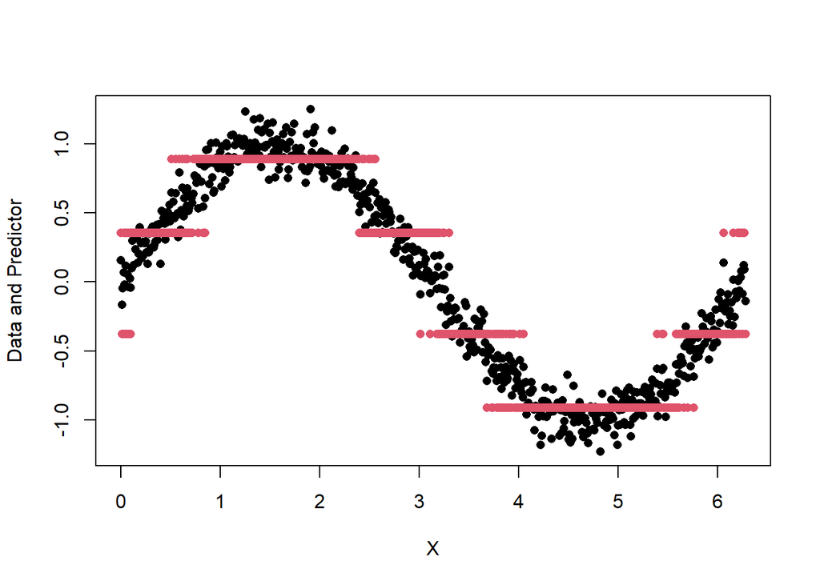

```r
data$learner12<-data$learner1+simpleLearner(residuals1)
myPlot(data)
```

The combination of the two simple learners creates a pattern with 4 levels which captures the signal much better.

Create new residuals and repeat the iteration step one more time.

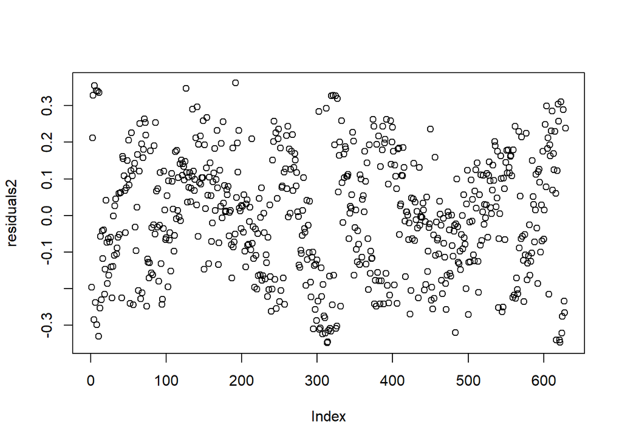

```r
residuals2<-data$signal-data$learner12
plot(residuals2)
```

```r
(sd2<-sd(residuals2))
```

```
## [1] 0.1599267
```

```r
c(sd(data$signal),sd1,sd2)
```

```
## [1] 0.7170284 0.3199656 0.1599267
```

This step again significantly reduced standard deviation of the residuals.

Create new learner combining 3 iterations.

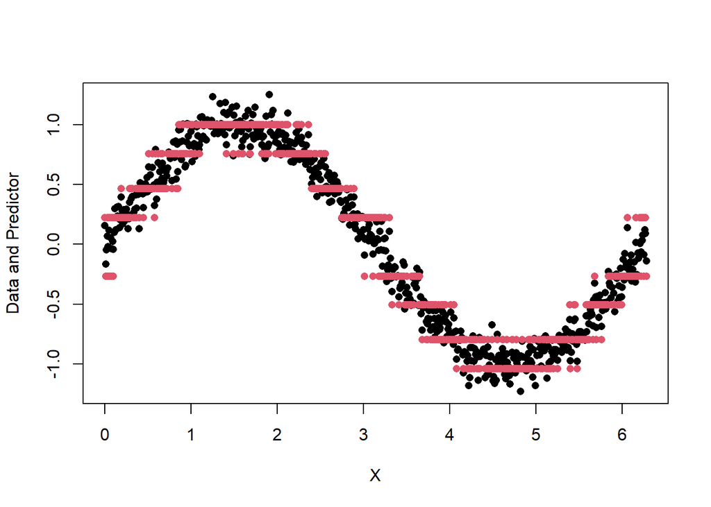

```r
data$learner123<-data$learner12+simpleLearner(residuals2)
myPlot(data)
```

At 8 levels the signal is captured better.

Make another iteration.

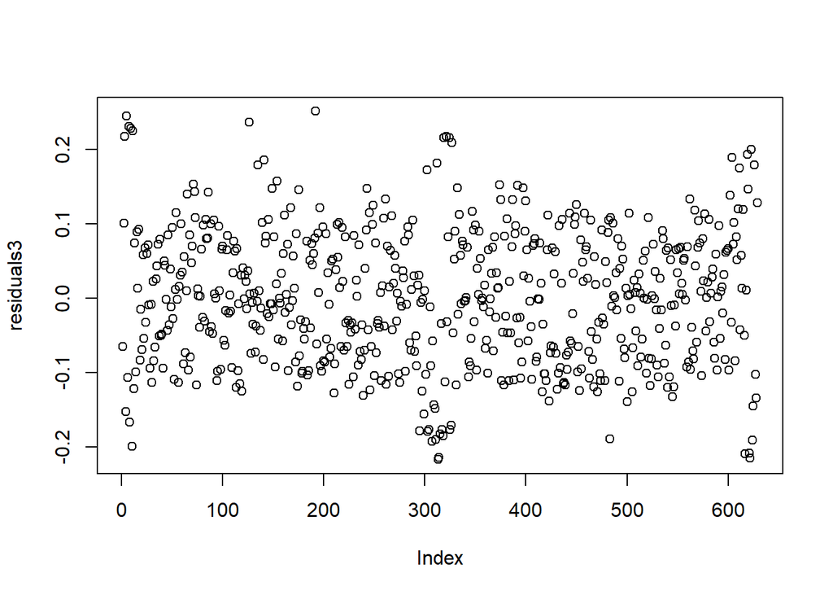

```r
residuals3<-data$signal-data$learner123
plot(residuals3)
```

```r
(sd3<-sd(residuals3))
```

```
## [1] 0.08886605
```

```r
c(sd(data$signal),sd1,sd2,sd3)
```

```
## [1] 0.71702843 0.31996564 0.15992673 0.08886605
```

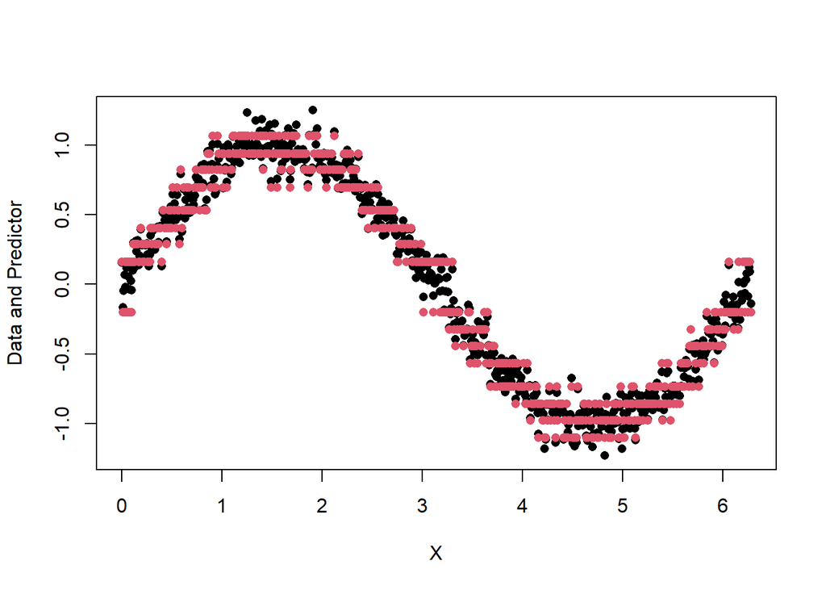

```r
data$learner1234<-data$learner123+simpleLearner(residuals3)
myPlot(data)
```

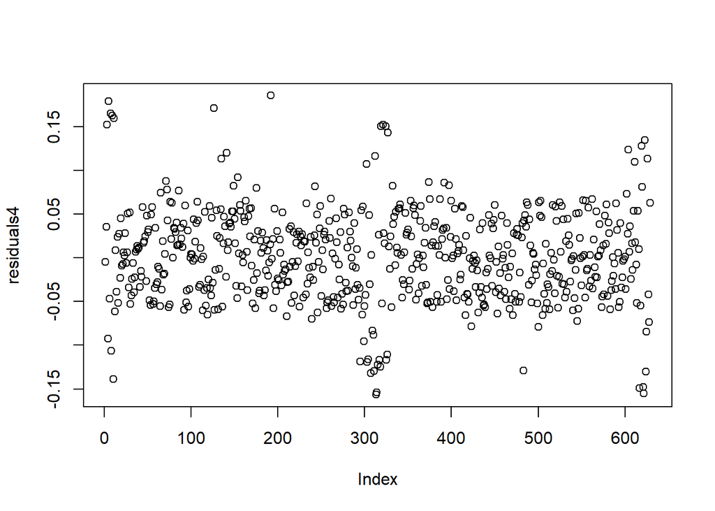

```r
residuals4<-data$signal-data$learner1234
plot(residuals4)
```

```r
(sd4<-sd(residuals4))
```

```
## [1] 0.05175807
```

```r
c(sd(data$signal),sd1,sd2,sd3,sd4)
```

```
## [1] 0.71702843 0.31996564 0.15992673 0.08886605 0.05175807
```

Finally, try one more time.

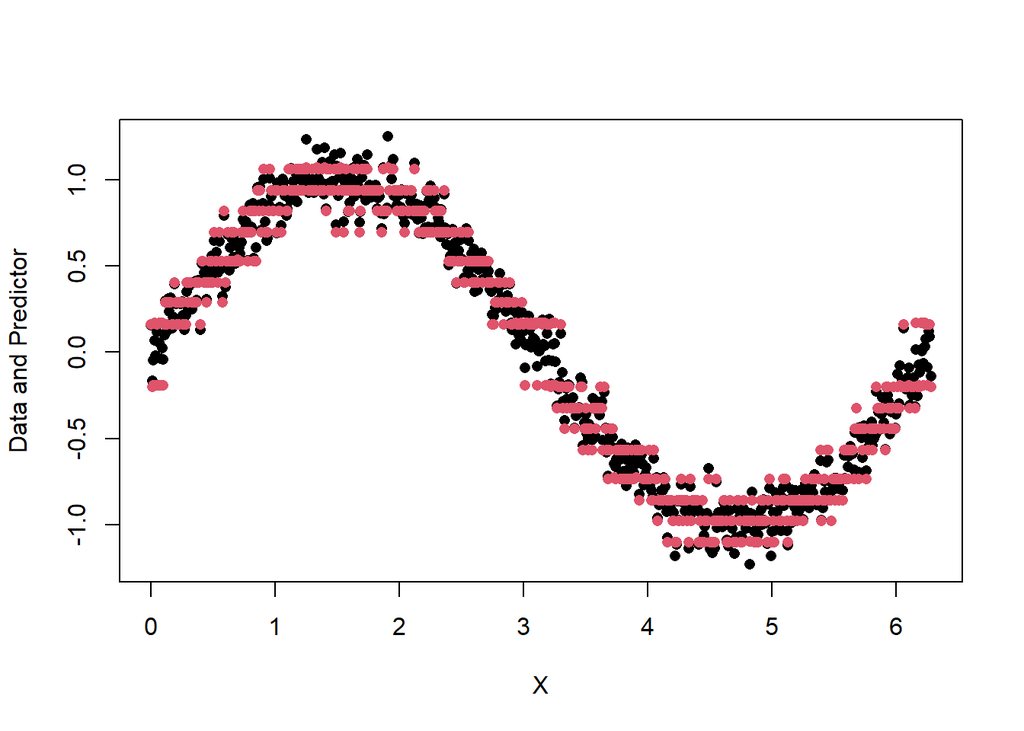

```r
data$learner12345<-data$learner1234+simpleLearner(residuals4)
myPlot(data)
```

Sequential combination of several very simple learners achieved very accurate description of complex nonlinear pattern of the original signal.

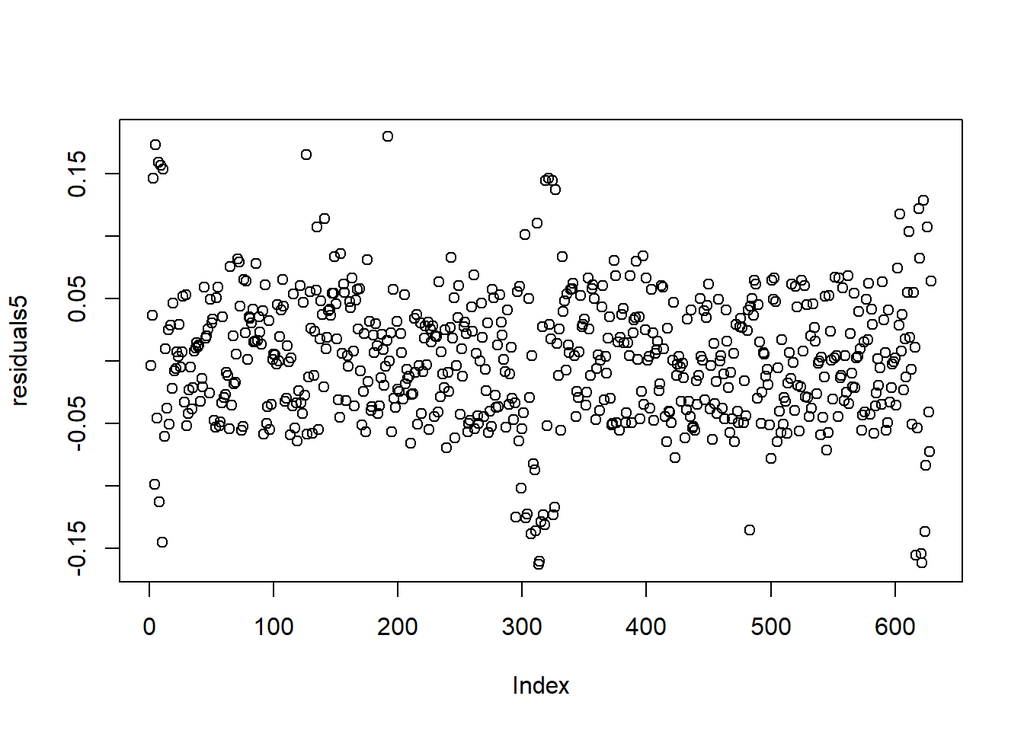

```r
residuals5<-data$signal-data$learner12345
plot(residuals5)
```

```r
(sd5<-sd(residuals5))
```

```
## [1] 0.05168095
```

```r
c(sd(data$signal),sd1,sd2,sd3,sd4,sd5)
```

```
## [1] 0.71702843 0.31996564 0.15992673 0.08886605 0.05175807 0.05168095
```

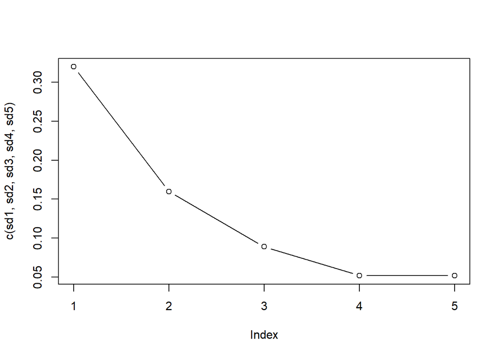

```r
plot(c(sd1,sd2,sd3,sd4,sd5),type="b")
```

Improvement of the standard deviation of the residuals has slowed down, stop the process.

Note that the standard deviation of the remaining noise is lower than the standard deviation of the originally simulated noise $\epsilon_i$.

# 3 Regression

## 3.1 Example: Predicting Baseball Players' Salaries

Use the Hitters data from the ISLR library for a simple example

```r
library(ISLR)
library(knitr)
```

Remove missing entries and take logs of salaries.

```r
data(Hitters)
# Remove incomplete cases
Hitters <- na.omit(Hitters)
# log transform Salary to make it a bit more normally distributed
Hitters$Salary <- log(Hitters$Salary)
kable(head(Hitters,3))
```

|  | AtBat | Hits | HmRun | Runs | RBI | Walks | Years | CAtBat | CHits | CHmRun | CRuns | CRBI | CWalks | League | Division | PutOuts | Assists | Errors | Salary | NewLeague |
| --- | --- | --- | --- | --- | --- | --- | --- | --- | --- | --- | --- | --- | --- | --- | --- | --- | --- | --- | --- | --- |
| -Alan Ashby | 315 | 81 | 7 | 24 | 38 | 39 | 14 | 3449 | 835 | 69 | 321 | 414 | 375 | N | W | 632 | 43 | 10 | 6.163315 | N |
| -Alvin Davis | 479 | 130 | 18 | 66 | 72 | 76 | 3 | 1624 | 457 | 63 | 224 | 266 | 263 | A | W | 880 | 82 | 14 | 6.173786 | A |
| -Andre Dawson | 496 | 141 | 20 | 65 | 78 | 37 | 11 | 5628 | 1575 | 225 | 828 | 838 | 354 | N | E | 200 | 11 | 3 | 6.214608 | N |

### 3.1.1 Random Forest

Random forest method is implemented in R package **randomForest**.

Description:  
randomForest implements Breiman's random forest algorithm (based on Breiman and Cutler's original Fortran code) for classification and regression. It can also be used in unsupervised mode for assessing proximities among data points.  
Reference manual: randomForest.pdf.

```r
library(randomForest)
```

#### 3.1.1.1 Default arguments

Set seed for reproducibility and grow a forest.

```r
set.seed(0)
rfSalary <- randomForest(Salary~.,ntree=500, data=Hitters,importance=TRUE)
print(rfSalary)
```

```
##
## Call:
##  randomForest(formula = Salary ~ ., data = Hitters, ntree = 500,      importance = TRUE)
##                Type of random forest: regression
##                      Number of trees: 500
## No. of variables tried at each split: 6
##
##           Mean of squared residuals: 0.1797216
##                     % Var explained: 77.18
```

- The "mean of squared residuals" output $MSE_{OOB}$ is computed on the basis of out-of-bag sample.
- The "% Var explained" output is
  $$100\left( 1-\frac{MSE_{OOB}}{\widehat{\sigma _{y}^{2}}} \right),$$
  where the OOB estimate of target variable $\widehat{\sigma _{y}^{2}}$ is computed with $n$ as divisor (rather than $n-1$).

The package has extractor function `importance()` for variable importance measures as produced by randomForest.

Here are the definitions of the variable importance measures:

- The first measure is computed from permuting OOB data: For each tree, the prediction error on the out-of-bag portion of the data is recorded (error rate for classification, MSE for regression).  
  Then the same is done after permuting each predictor variable.  
  The difference between the two are then averaged over all trees, and normalized by the standard deviation of the differences.  
  Intuition behind the measure: if predictor is not important, permuting its values will not make prediction power worse.

If the standard deviation of the differences is equal to 0 for a variable, the division is not done (but the average is almost always equal to 0 in that case).

- The second measure is the total decrease in node impurities from splitting on the variable, averaged over all trees.  
  For classification, the node impurity is measured by the Gini index.  
  For regression, it is measured by residual sum of squares.

```r
importance(rfSalary)
```

```
##               %IncMSE IncNodePurity
## AtBat     11.04473170     7.8273993
## Hits       8.14875343     8.3361150
## HmRun      4.05788047     2.7904848
## Runs       8.57518525     5.4225820
## RBI        6.96549878     6.5984694
## Walks      9.95461274     6.4594625
## Years     10.97301275     7.7202911
## CAtBat    17.22770590    38.9365723
## CHits     17.14070336    35.8528658
## CHmRun     8.14862853     7.7629311
## CRuns     14.68631048    31.3141380
## CRBI      13.70222745    19.9732594
## CWalks    10.36356473    17.8513066
## League    -0.15644265     0.2771139
## Division   0.05418096     0.2544020
## PutOuts    3.18723063     3.1526201
## Assists    0.63876373     1.6713038
## Errors     2.40006727     1.6814031
## NewLeague  0.33641580     0.3798795
```

We can also sort variables according to its importances and plot them

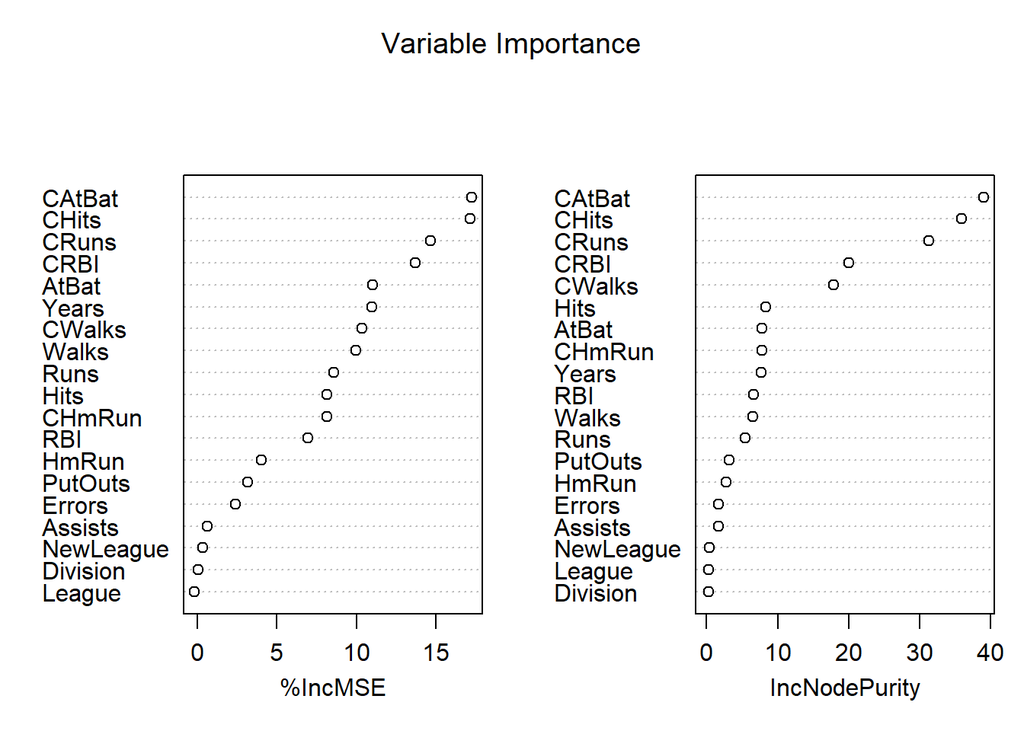

```r
varImpPlot(rfSalary, main="Variable Importance")
```

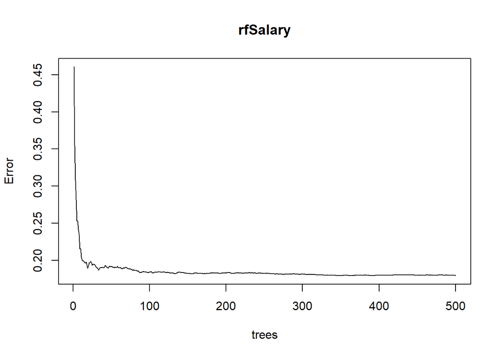

```r
plot(rfSalary)
```

The last plot shows that we may significantly reduce the number of trees without loosing accuracy.

#### 3.1.1.2 Reduced number of trees

```r
set.seed(0)
rfSalary200 <- randomForest(Salary~., ntree=200, data=Hitters,importance=TRUE)
print(rfSalary200)
```

```
##
## Call:
##  randomForest(formula = Salary ~ ., data = Hitters, ntree = 200,      importance = TRUE)
##                Type of random forest: regression
##                      Number of trees: 200
## No. of variables tried at each split: 6
##
##           Mean of squared residuals: 0.183184
##                     % Var explained: 76.74
```

Compare forests with 500 and 200 trees:

```r
rbind(T200=c(mse=tail(rfSalary200$mse,1),rsq=tail(rfSalary200$rsq,1)),
         T500=c(mse=tail(rfSalary$mse,1),rsq=tail(rfSalary$rsq,1)))
```

```
##            mse       rsq
## T200 0.1831840 0.7674318
## T500 0.1797216 0.7718275
```

Does the relative importance change?

```r
cbind(T200=row.names(rfSalary200$importance),T500=row.names(rfSalary$importance))
```

```
##       T200        T500
##  [1,] "AtBat"     "AtBat"
##  [2,] "Hits"      "Hits"
##  [3,] "HmRun"     "HmRun"
##  [4,] "Runs"      "Runs"
##  [5,] "RBI"       "RBI"
##  [6,] "Walks"     "Walks"
##  [7,] "Years"     "Years"
##  [8,] "CAtBat"    "CAtBat"
##  [9,] "CHits"     "CHits"
## [10,] "CHmRun"    "CHmRun"
## [11,] "CRuns"     "CRuns"
## [12,] "CRBI"      "CRBI"
## [13,] "CWalks"    "CWalks"
## [14,] "League"    "League"
## [15,] "Division"  "Division"
## [16,] "PutOuts"   "PutOuts"
## [17,] "Assists"   "Assists"
## [18,] "Errors"    "Errors"
## [19,] "NewLeague" "NewLeague"
```

#### 3.1.1.3 Variation of number of variables in split

```r
mtryVec<-1:19
set.seed(0)
mtryQuality<-t(sapply(mtryVec,
                      function(z) c(mse=tail(randomForest(Salary~.,
                                                          ntree=200,
                                                          data=Hitters,
                                                          importance=T,mtry=z)$mse,1),
                                    rsq=tail(randomForest(Salary~.,
                                                          ntree=200,
                                                          data=Hitters,
                                                          importance=T,
                                                          mtry=z)$rsq,1)
                                    )
                      )
               )
head(mtryQuality)
```

```
##            mse       rsq
## [1,] 0.2160327 0.7335060
## [2,] 0.1874388 0.7733105
## [3,] 0.1864688 0.7714732
## [4,] 0.1844576 0.7679577
## [5,] 0.1769003 0.7765539
## [6,] 0.1847133 0.7700715
```

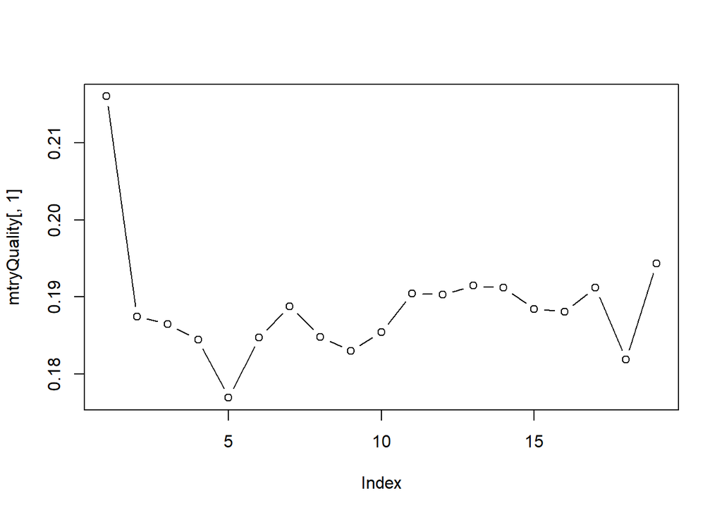

```r
plot(mtryQuality[,1],type="b")
```

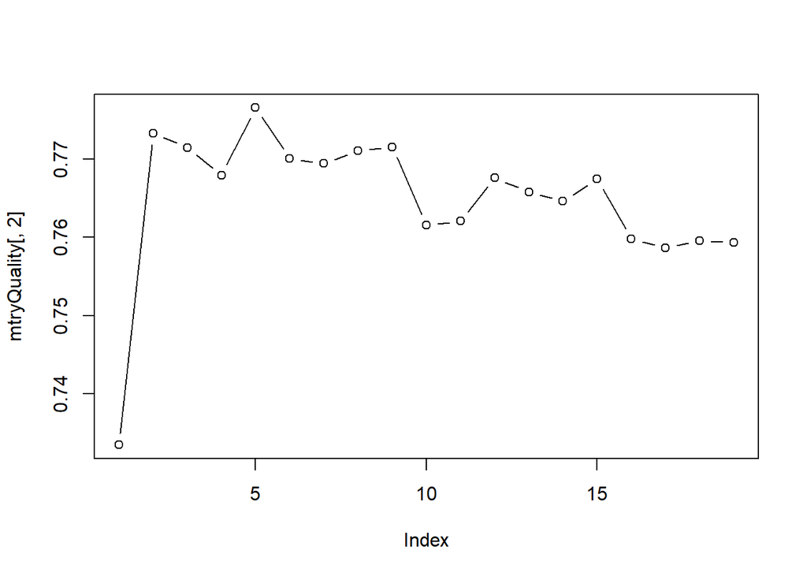

```r
plot(mtryQuality[,2],type="b")
```

Plotting the curves for different numbers of variables at each split suggests to use parameter `mtry` equal to 5.

Predicting and calculating RMSE for the random forest model.

```r
set.seed(0)
rfSalary200 <- randomForest(Salary~., ntree=200, data=Hitters,importance=F,mxtry=6)
print(rfSalary200)
```

```
##
## Call:
##  randomForest(formula = Salary ~ ., data = Hitters, ntree = 200,      importance = F, mxtry = 6)
##                Type of random forest: regression
##                      Number of trees: 200
## No. of variables tried at each split: 6
##
##           Mean of squared residuals: 0.1851932
##                     % Var explained: 76.49
```

```r
mean((Hitters$Salary-predict(rfSalary200))^2)
```

```
## [1] 0.1851932
```

### 3.1.2 Gradient Boosting

Analyze the same data using gradient boosting.

The method is implemented in [**xgboost**](https://cran.r-project.org/web/packages/xgboost/xgboost.pdf).

XGBoost is short for "Extreme Gradient Boosting".

It has several nice properties:

- Speed: it can automatically do parallel computation on Windows and Linux, with OpenMP.  
  It is generally over 10 times faster than the classical gbm.
- Input Type: it takes several types of input data:
  - Dense Matrix: R's dense matrix, i.e. matrix;
  - Sparse Matrix: R's sparse matrix, i.e. Matrix::dgCMatrix;
  - Data File: local data files;
  - xgb.DMatrix: its own class (recommended).
- Sparsity: it accepts sparse input for both tree booster and linear booster, and is optimized for sparse input ;
- Customization: it supports customized objective functions and evaluation functions.

```r
library(xgboost)
```

Set "objective" parameter.

```r
params <- list("objective" = "reg:squarederror")
```

`Xgboost` has large number of parameters.

Some of them are on the list in `params`.  
Commonly used ones are:

- `objective` objective function, typically:
  - `reg:squarederror` - for linear regression
  - `binary:logistic` - logistic regression for classification
- `eta` step size of each boosting step
- `max.depth` maximum depth of the tree
- `nthread` number of threads used in training, if not set, all threads are used.

Xgboost works only with numeric data while **Hitters** has several categorical columns. Convert them to integer and run cross validation.

```r
matrHitters = data.matrix(Hitters)[,-which(names(Hitters) == "Salary")]
target = Hitters$Salary
```

Run `xgb.cv()` to find the best number of iterations.

```r
set.seed(0)
cvSalary = xgb.cv(params=params, data = matrHitters, label = target,
                nfold = 3, nrounds = 50,prediction=T,verbose=F)
names(cvSalary)
```

```
## [1] "call"           "params"         "callbacks"      "evaluation_log"
## [5] "niter"          "nfeatures"      "folds"          "pred"
```

```r
(cvSalary.table<-cvSalary$evaluation_log)
```

```
##     iter train_rmse_mean train_rmse_std test_rmse_mean test_rmse_std
##  1:    1     3.888622000   2.084647e-02      3.8890477    0.04508231
##  2:    2     2.762874667   1.634184e-02      2.7607593    0.03659628
##  3:    3     1.976666000   1.673070e-02      2.0086927    0.05294984
##  4:    4     1.427120667   1.425882e-02      1.4949330    0.06730569
##  5:    5     1.041716000   1.233372e-02      1.1432113    0.06751280
##  6:    6     0.772617333   1.097000e-02      0.9080293    0.06529887
##  7:    7     0.583339000   9.951118e-03      0.7504347    0.06757955
##  8:    8     0.448386333   9.000428e-03      0.6569867    0.07683111
##  9:    9     0.353353000   1.037735e-02      0.6049643    0.07642384
## 10:   10     0.281631000   9.673184e-03      0.5693730    0.06779325
## 11:   11     0.231364667   1.115090e-02      0.5492353    0.05682818
## 12:   12     0.195154000   1.339173e-02      0.5389933    0.05496025
## 13:   13     0.168413333   1.575393e-02      0.5313350    0.05125806
## 14:   14     0.144351667   1.257319e-02      0.5241533    0.04992478
```

[output cut: 37 more lines]

Note effect of overfitting in the RMSE table.  
Optimal number of iterations minimizes squared mean square error `rmse`.

```r
(bestNR = which.min(cvSalary.table$test_rmse_mean))
```

```
## [1] 41
```

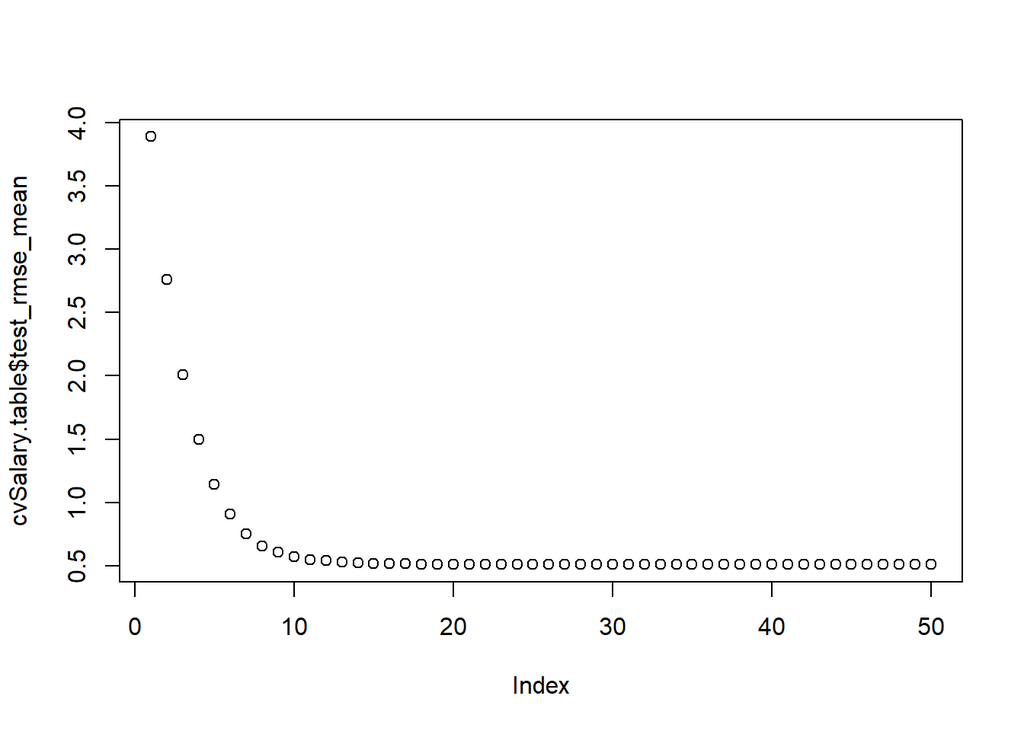

```r
plot(cvSalary.table$test_rmse_mean)
```

```r
cvSalary.table$test_rmse_mean[bestNR] #using bestNR
```

```
## [1] 0.5098337
```

Train the model using `bestNR` and calculate its RMSE using entire sample.

```r
modelSalary<-xgboost(data=matrHitters, label = target,params=params,
                     nrounds=bestNR,verbose=F,save_period=NULL)
names(modelSalary)
```

```
## [1] "handle"         "raw"            "niter"          "evaluation_log"
## [5] "call"           "params"         "callbacks"      "feature_names"
## [9] "nfeatures"
```

```r
mean((target-predict(modelSalary,newdata=matrHitters))^2)
```

```
## [1] 0.000310588
```

This mean squared error is small in comparison with the order of magnitude of test RMSE which may be a sign of overfitting.

#### 3.1.2.1 Tuning parameters

A way of tuning parameters of the method is a modification of this [blog](http://stats.stackexchange.com/questions/171043/how-to-tune-hyperparameters-of-xgboost-trees)

Prepare the grid of parameters.

```r
# xgboost task parameters
folds <- 3
eval_metric = list("rmse")  # evaluation metric for validation

# Parameters grid to search
eta = c(.3,.15,0.05)
max_depth = c(4,5,6)
nrounds <- c(seq(from=30,to=90,by=10),26)

# Table to track performance from each worker node
res <- data.frame(Value=numeric(),Eta=numeric(),Max_Depth=numeric(),Nrounds=numeric())
```

Make fitting function.

```r
# Fitting function for iterations
xgbCV <- function (Inputs) {
  myEta<-Inputs$eta
  myMax_depth<-Inputs$max_depth
  myNRounds<-Inputs$n_Rounds
  set.seed(0)
  fit <- xgb.cv(
    params =list(eta=myEta,max_depth=myMax_depth),
    data = matrHitters,
    metrics=eval_metric,
    objective = "reg:squarederror",
    label = target,
    nfold = folds,
    nrounds = myNRounds,
    verbose=F
  )
  mybestNR = which.min(fit$evaluation_log$test_rmse_mean)
  val <- fit$evaluation_log$test_rmse_mean[mybestNR]
  res <<- rbind(res,c(val,myEta,myMax_depth,mybestNR))

  return(val)
}
```

Run search on the grid.

```r
library(NMOF)
```

```r
sol <- gridSearch(
  fun = xgbCV,
  levels = list(eta=eta,max_depth=max_depth,n_Rounds=nrounds),
  method = 'loop',
  keepNames = TRUE,
  asList = TRUE
)
```

```
## 3 variables with 3, 3, 8 levels: 72 function evaluations required.
```

Showing optimal set of parameters.

```r
sol$minlevels
```

```
## $eta
## [1] 0.15
##
## $max_depth
## [1] 4
##
## $n_Rounds
## [1] 40
```

Training the model with optimal parameters.

```r
# Train model given tuned parameters
params<-sol$minlevels[1:2]
#set.seed(0)
xgbSalary.tuned<-xgboost(data = matrHitters,
        label = target,
        objective="reg:squarederror",
        params = params,
        nrounds = sol$minlevels$n_Rounds,
        verbose=F,save_period=NULL)
c(Default=mean((target-predict(modelSalary,newdata=matrHitters))^2),
  Tuned=mean((target-predict(xgbSalary.tuned,newdata=matrHitters))^2))
```

```
##     Default       Tuned
## 0.000310588 0.024650811
```

This does not seem like improvement. Trying parameters manually.

Increasing tree depth to 6.

```r
params<-list(eta=.15,max_depth=6)
xgbSalary.tuned<-xgboost(data = matrHitters,
        label = target,
        objective="reg:squarederror",
        params = params,
        nrounds = sol$minlevels$n_Rounds,
        verbose=F,save_period=NULL)
c(Default=mean((target-predict(modelSalary,newdata=matrHitters))^2),
  Tuned=mean((target-predict(xgbSalary.tuned,newdata=matrHitters))^2))
```

```
##     Default       Tuned
## 0.000310588 0.009331554
```

Increasing `eta` to the default value of 0.3,

```r
params<-list(eta=.3,max_depth=6)
xgbSalary.tuned<-xgboost(data = matrHitters,
        label = target,
        objective="reg:squarederror",
        params = params,
        nrounds = sol$minlevels$n_Rounds,
        verbose=F,save_period=NULL)
c(Default=mean((target-predict(modelSalary,newdata=matrHitters))^2),
  Tuned=mean((target-predict(xgbSalary.tuned,newdata=matrHitters))^2))
```

```
##      Default        Tuned
## 0.0003105880 0.0003717729
```

## 3.2 Example: Large Number of Predictors

Consider the example analyzed in the workshop Linear Regression with Large Number of Predictors. Simulate data

```r
N = 500
set.seed(0)
Epsilon<-rnorm(N,0,1)
X<-rnorm(N*N,0,2)
dim(X)<-c(N,N)
colnames(X)<-paste0("X",1:N)
slopesSet<-runif(N,1,3)
Y<-sapply(2:N,function(z) 1+X[,1:z]%*%slopesSet[1:z]+Epsilon)
head(X[,1:5])
```

```
##              X1         X2         X3          X4         X5
## [1,] -1.2527365 -0.5737031  0.1575234  0.88869164 -1.0643804
## [2,]  0.9626707  3.6822138 -0.1028412  0.02385876 -0.7399334
## [3,]  3.3905422 -0.3135286 -0.5215483 -0.01856009  2.3417986
## [4,] -3.5224526 -2.7796053  3.1325364 -0.60475511 -0.9291356
## [5,]  0.3960260 -2.9462080 -0.7440302  0.98471004 -0.6042920
## [6,]  0.7946982 -0.1390379  3.4838889 -1.20543924  2.7827418
```

```r
m = 440
completeModelDataFrame <- data.frame(Y=Y[,m-1],X[,1:m])
```

### 3.2.1 Random forest

```r
set.seed(0)
rfManyReg <- randomForest(Y~., data=completeModelDataFrame)
print(rfManyReg)
```

```
##
## Call:
##  randomForest(formula = Y ~ ., data = completeModelDataFrame)
##                Type of random forest: regression
##                      Number of trees: 500
## No. of variables tried at each split: 146
##
##           Mean of squared residuals: 7018.218
##                     % Var explained: 6.78
```

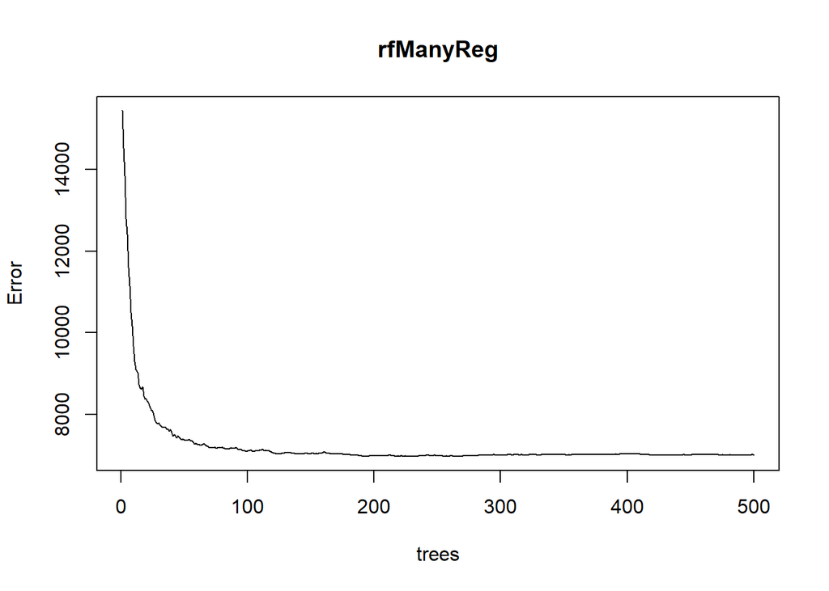

```r
plot(rfManyReg)
```

It is a little better than regression tree (see previous lecture) but far behind the linear model that gave us MSE = 52.070656.

Number of trees in the forest may be reduced:

```r
which.min(rfManyReg$mse)
```

```
## [1] 267
```

```r
which.min(rfManyReg$mse[1:100])
```

```
## [1] 99
```

```r
set.seed(0)
rfManyReg <- randomForest(Y~., data=completeModelDataFrame,ntree=which.min(rfManyReg$mse[1:100]))
print(rfManyReg)
```

```
##
## Call:
##  randomForest(formula = Y ~ ., data = completeModelDataFrame,      ntree = which.min(rfManyReg$mse[1:100]))
##                Type of random forest: regression
##                      Number of trees: 99
## No. of variables tried at each split: 146
##
##           Mean of squared residuals: 7105.823
##                     % Var explained: 5.62
```

#### 3.2.1.1 Importance of predictors

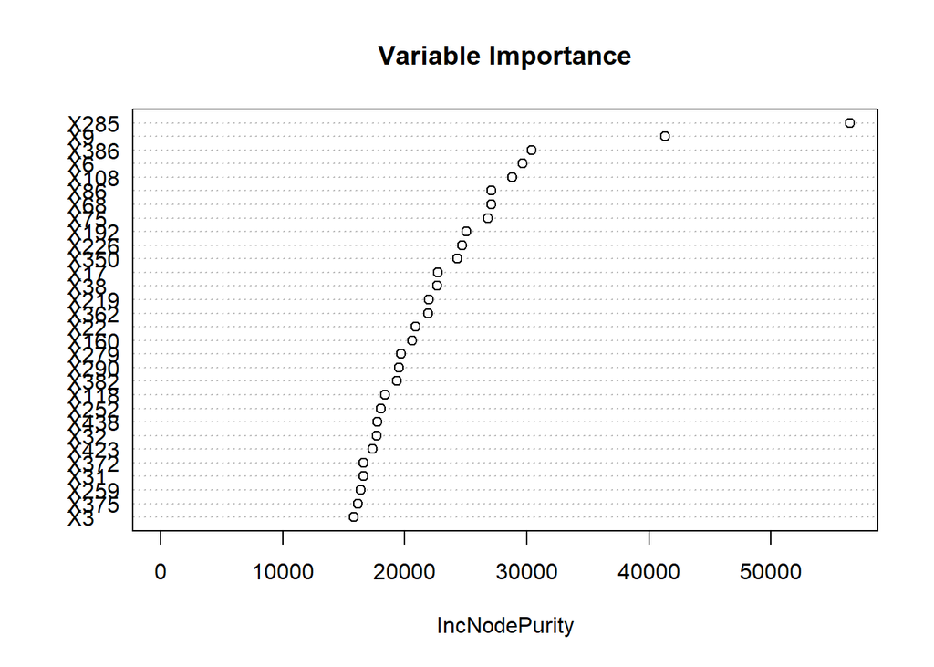

```r
varImpPlot(rfManyReg, main="Variable Importance")
```

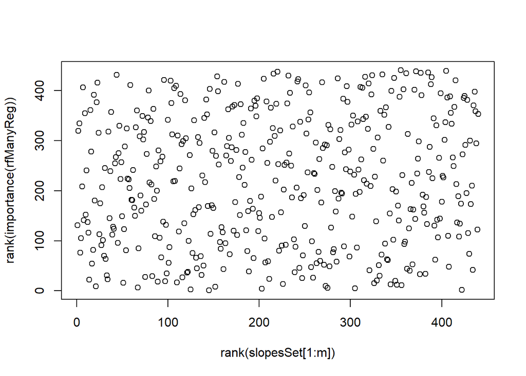

```r
plot(rank(slopesSet[1:m]),rank(importance(rfManyReg)))
```

```r
head(cbind(rank(slopesSet[1:m]),rank(importance(rfManyReg))))
```

```
##      [,1] [,2]
## [1,]    2  319
## [2,]  313  405
## [3,]   59  411
## [4,]  104  375
## [5,]  188  159
## [6,]  220  437
```

Recall that all parameters are simulated as significant and all predictors are independent by construction.  
The larger the coefficient - the more significant should be the predictor.  
Random tree may not be assigning importance correctly in this case.

### 3.2.2 Gradient boosting

```r
params <- list("objective" = "reg:squarederror")
set.seed(0)
gbManyReg = xgb.cv(params=params, data =data.matrix(completeModelDataFrame[,-1]),
                   label = completeModelDataFrame[,1],
                   nfold = 5, nrounds = 100,verbose=F)
(bestNR = which.min(gbManyReg$test.rmse.mean))
```

```
## integer(0)
```

```r
gbManyReg$test.rmse.mean[bestNR]^2
```

```
## numeric(0)
```

We see that some advanced models can not treat multidimentsional data while linear model is able to fit them.

**General Conclusion**. Linear model may not be the best choice in all cases. But if it works - it works better than other models.  
Same is true in general about any parametric model in comparison with non-parametric approaches.

# 4 Classification

## 4.1 Otto Product Classification Example

In this example we use data set provided by **Otto Group** for **Kaggle** competition [Otto Group Product Classification Challenge](https://www.kaggle.com/c/otto-group-product-classification-challenge).

Otto Group needed categorizing about 200,000 unspecified products into 9 classes based on 93 unspecified features. For simplicity we reduced the number of visitors and the number of classes.

Assign your path to `DTTrain.csv` to variable `datapath`.

Load the data set.

```r
library(fBasics)
```

```r
Data = read.csv(paste(datapath,'DTTrain.csv',sep='/'),header=TRUE)
Data$target<-as.factor(Data$target)
dim(Data) # dataset dimensions
```

```
## [1] 10233    95
```

```r
# data content
kable(head(Data[,1:5],3))
```

| time | feat_1 | feat_2 | feat_3 | feat_4 |
| --- | --- | --- | --- | --- |
| 45652 | 0 | 0 | 0 | 0 |
| 225646 | 0 | 0 | 0 | 0 |
| 345735 | 0 | 0 | 0 | 0 |

```r
kable(Data[1:3,(ncol(Data)-4):ncol(Data)])
```

| feat_90 | feat_91 | feat_92 | feat_93 | target |
| --- | --- | --- | --- | --- |
| 0 | 0 | 1 | 0 | Class_5 |
| 0 | 1 | 1 | 0 | Class_3 |
| 0 | 0 | 0 | 0 | Class_5 |

Partition data into train (2/3) and test (1/3) sets.

```r
set.seed(13)
testInd = sample(nrow(Data), nrow(Data)/3)
xTrain = Data[-testInd,-c(1,ncol(Data))]
xTest = Data[testInd,-c(1,ncol(Data))]
yTrain = as.factor(Data$target[-testInd])
yTest = as.factor(Data$target[testInd])
```

### 4.1.1 Random forest

Fit random forest to the train data and make prediction on the test data.

```r
rfOtto <- randomForest(yTrain~., data=xTrain,ntree=100)
rfPred <- predict(rfOtto, xTest, type="prob")
rfPred[1:5,]
```

```
##      Class_1 Class_2 Class_3 Class_4 Class_5
## 9152    0.22    0.06    0.00    0.07    0.65
## 5989    0.38    0.08    0.08    0.03    0.43
## 717     0.19    0.19    0.01    0.12    0.49
## 4870    0.00    0.00    1.00    0.00    0.00
## 944     0.00    0.99    0.00    0.01    0.00
```

Use Multiclass logloss for estimating prediction quality.

```r
MultiLogLoss <- function(act, pred)
{
  eps = 1e-15;
  nr <- nrow(pred)
  pred = matrix(sapply( pred, function(x) max(eps,x)), nrow = nr)
  pred = matrix(sapply( pred, function(x) min(1-eps,x)), nrow = nr)
  #normalize rows
  ll = sum(act*log(sweep(pred, 1, rowSums(pred), FUN="/")))
  ll = -ll/nrow(act)
  return(ll);
}
```

Calculate it for random forest

```r
library(dummies)
```

Create matrix of true values indicators using function `dummy.data.frame()` from library `dummies`.

```r
rf_target_IndMat<-dummy.data.frame(data=as.data.frame(yTest),
                                     sep="_", verbose=F,
                                     dummy.class="ALL")
rf_target_IndMat[1:10,]
```

```
##    yTest_Class_1 yTest_Class_2 yTest_Class_3 yTest_Class_4 yTest_Class_5
## 1              0             0             0             0             1
## 2              1             0             0             0             0
## 3              0             0             0             0             1
## 4              0             0             1             0             0
## 5              0             1             0             0             0
## 6              0             1             0             0             0
## 7              0             0             0             0             1
## 8              0             0             0             1             0
## 9              0             1             0             0             0
## 10             0             0             1             0             0
```

```r
dim(rf_target_IndMat)
```

```
## [1] 3411    5
```

Then log loss is:

```r
(rfLogLoss = MultiLogLoss(rf_target_IndMat,rfPred))
```

```
## [1] 0.4100088
```

### 4.1.2 Gradient boosting

Function `xgboost()` accepts numeric matrices (not data frames) as input data and class labels should be integers starting from zero. So we need some conversion.

```r
xgbTrain = data.matrix(xTrain)
xgbTest = data.matrix(xTest)
yTrain = as.integer(yTrain)-1
yTest = as.integer(yTest)-1
table(yTrain)
```

```
## yTrain
##    0    1    2    3    4
##  650 2635  927  990 1620
```

```r
numClasses = max(yTrain) + 1
param <- list("objective" = "multi:softprob",
              "eval_metric" = "mlogloss",
              "num_class" = numClasses)
```

The choice of `"objective" = "multi:softprob"` represents generalization of logistic link into multiple classes and returns a matrix of class probabilities, as opposed to `"objective" = "multi:softmax"` which returns the class of maximum probability.

Sometimes it is important to use cross-validation to examine the model, for example, in order to find optimal number of iterations.  
In library `xgboost` this is done by function `xgb.cv()`.

Fit boosting model.

```r
cv.nround <- 10
cv.nfold <- 3
set.seed(1)
(bst.cv = xgb.cv(param=param, data = xgbTrain, label = yTrain,
                nfold = cv.nfold, nrounds = cv.nround,verbose=F))
```

```
## ##### xgb.cv 3-folds
##  iter train_mlogloss_mean train_mlogloss_std test_mlogloss_mean
##     1           1.1633397       0.0017701274          1.1883910
##     2           0.9232927       0.0009151584          0.9658680
##     3           0.7625693       0.0031412360          0.8204233
##     4           0.6461203       0.0036961682          0.7139777
##     5           0.5580793       0.0035759005          0.6346760
##     6           0.4911670       0.0029172814          0.5746057
##     7           0.4376327       0.0026616717          0.5285550
##     8           0.3947160       0.0031888720          0.4922293
##     9           0.3590817       0.0048939766          0.4638753
##    10           0.3285080       0.0051704896          0.4403093
##  test_mlogloss_std
##        0.004829907
##        0.009605331
##        0.010354695
##        0.011473206
##        0.010616465
##        0.009800490
##        0.010210736
##        0.010975021
##        0.010580599
##        0.011681428
```

Since xerror continues decreasing in the process of cross validation we know that the model is not over-fitting.  
But this also may mean that the fit can be better.  
Make prediction with this number of rounds.

```r
bst = xgboost(param=param, data = xgbTrain, label = yTrain,
              nrounds=cv.nround,verbose=F,save_period=NULL)
xgbPred <- matrix(predict(bst, xgbTest), ncol = numClasses, byrow = TRUE)
head(xgbPred)
```

```
##            [,1]       [,2]       [,3]       [,4]       [,5]
## [1,] 0.07005556 0.06218502 0.02946227 0.06553441 0.77276278
## [2,] 0.52333015 0.13315237 0.07728224 0.13396128 0.13227394
## [3,] 0.20102398 0.15436779 0.03727620 0.07015130 0.53718072
## [4,] 0.01824003 0.01389743 0.93387479 0.01442061 0.01956707
## [5,] 0.02718644 0.91611904 0.01296168 0.02706998 0.01666282
## [6,] 0.02519860 0.91257602 0.01502645 0.01869680 0.02850214
```

Compare prediction quality of random forest and gradient boosting

```r
gb_target_IndMat<-dummy.data.frame(data=as.data.frame(yTest),
                                     sep="_", verbose=F,
                                     dummy.class="ALL")
print(list(RF = rfLogLoss ,XGB = MultiLogLoss(gb_target_IndMat,xgbPred)))
```

```
## $RF
## [1] 0.4100088
##
## $XGB
## [1] 0.4249591
```

**Try to play with `xgboost()` parameters (nrounds, eta, max.depth etc.) in order to improve its forecast.**  
**Can it do better than random forest on these data?**

(Skipped Code)

```r
print(list(RF = rfLogLoss ,XGB = MultiLogLoss(gb_target_IndMat,xgbPred)))
```

```
## $RF
## [1] 0.4100088
##
## $XGB
## [1] 0.3232496
```

## 4.2 Identification of Spoken Letters (ISOLET) Example

Data for this example are from UCI repository: Lichman, M. (2013), [UCI Machine Learning Repository](http://archive.ics.uci.edu/ml). Irvine, CA: University of California, School of Information and Computer Science.

The data set is [ISOLET (Isolated Letter Speech Recognition)](http://archive.ics.uci.edu/ml/machine-learning-databases/isolet/).

The version of the data with modified format used in the example was created at [Win-Vector LLC](http://www.win-vector.com/site/) and the example is covered in their [video course](https://www.youtube.com/watch?v=WZvPUGNJg18). The materials for their lecture including the data and the code are [here](http://winvector.github.io/IntroductionToDataScience/Sec02_Lesson013_GBM/).

We only use the part of the code that prepares the data and the recommendations on the call of `gbm()`.

Data Set Information:

This data set was generated as follows. 150 subjects spoke the name of each letter of the alphabet twice. Hence, we have 52 training examples from each speaker.  
The data contain different characteristics of the sounds, for example characteristics of [waveforms](http://www.bespokenart.com/names/see_your_name.html).  
The features include spectral coefficients; contour features, sonorant features, pre-sonorant features, and post-sonorant features.  
Exact order of appearance of the features is not known.

The speakers are grouped into sets of 30 speakers each, and are referred to as isolet1, isolet2, isolet3, isolet4, and isolet5.  
The data appear in ["isolet1+2+3+4.data"](http://winvector.github.io/IntroductionToDataScience/Sec02_Lesson012_SVM/isolet1+2+3+4.data.gz) in sequential order: first the speakers from isolet1, then isolet2, and so on.  
The test set, ["isolet5"](http://winvector.github.io/IntroductionToDataScience/Sec02_Lesson012_SVM/isolet5.data.gz), is a separate file.

The total number of observations in ISOLET should be $150 \times 26 \times 2 = 7800$. Of them 6238 are in the training set and 1559 are in the test set. Three observations are missing for some reason.

Attribute Information:

The features are described in the paper by Cole and Fanty:

Fanty, M., Cole, R. (1991). Spoken letter recognition. In Lippman, R. P., Moody, J., and Touretzky, D. S. (Eds). Advances in Neural Information Processing Systems 3. San Mateo, CA: Morgan Kaufmann

See also:

[Dietterich, T. G., Bakiri, G. (1991) Error-correcting output codes: A general method for improving multiclass inductive learning programs. Proceedings of the Ninth National Conference on Artificial Intelligence (AAAI-91), Anaheim, CA: AAAI Press](https://www.aaai.org/Papers/AAAI/1991/AAAI91-089.pdf).

[Dietterich, T. G., Bakiri, G. (1994) Solving Multiclass Learning Problems via Error-Correcting Output Codes](https://www.jair.org/media/105/live-105-1426-jair.pdf).

[Fanty, M., Cole, R. (1991). Spoken letter recognition. In Lippman, R. P., Moody, J., and Touretzky, D. S. (Eds). Advances in Neural Information Processing Systems 3. San Mateo, CA: Morgan Kaufmann](http://papers.nips.cc/paper/295-spoken-letter-recognition.pdf).

Creators of the data:

Ron Cole and Mark Fanty:  
Department of Computer Science and Engineering, Oregon Graduate Institute, Beaverton, OR 97006. cole '@' cse.ogi.edu, fanty '@' cse.ogi.edu cited above.

Donor:

Tom Dietterich Department of Computer Science Oregon State University, Corvallis, OR 97331 tgd '@' cs.orst.edu

Read the data

```r
# Actual example
# isolet data from https://archive.ics.uci.edu/ml/datasets/ISOLET
library('ggplot2')
library('gbm')
```

```r
dTrain = read.table(paste0(datapath,"isolet1234.data.gz"),
              header=FALSE,sep=',',
              stringsAsFactors=FALSE,blank.lines.skip=TRUE)
dTrain$isTest <- FALSE
dTest = read.table(paste0(datapath,"isolet5.data.gz"),
              header=FALSE,sep=',',
              stringsAsFactors=FALSE,blank.lines.skip=TRUE)
dTest$isTest <- TRUE
d <- rbind(dTrain,dTest)
dim(d)
```

```
## [1] 7797  619
```

```r
d[1:5,1:10]
```

```
##        V1      V2     V3     V4      V5      V6      V7      V8      V9     V10
## 1 -0.4394 -0.0930 0.1718 0.4620  0.6226  0.4704  0.3578  0.0478 -0.1184 -0.2310
## 2 -0.4348 -0.1198 0.2474 0.4036  0.5026  0.6328  0.4948  0.0338 -0.0520 -0.1302
## 3 -0.2330  0.2124 0.5014 0.5222 -0.3422 -0.5840 -0.7168 -0.6342 -0.8614 -0.8318
## 4 -0.3808 -0.0096 0.2602 0.2554 -0.4290 -0.6746 -0.6868 -0.6650 -0.8410 -0.9614
## 5 -0.3412  0.0946 0.6082 0.6216 -0.1622 -0.3784 -0.4324 -0.4358 -0.4966 -0.5406
```

```r
d[1:5,610:619]
```

```
##      V610    V611    V612    V613   V614    V615   V616    V617 V618 isTest
## 1  0.2052  0.3846  0.3590  0.5898 0.3334  0.6410 0.5898 -0.4872    1  FALSE
## 2  0.2954  0.2046  0.4772  0.0454 0.2046  0.4318 0.4546 -0.0910    1  FALSE
## 3 -0.0476 -0.1746  0.0318 -0.0476 0.1112  0.2540 0.1588 -0.4762    2  FALSE
## 4 -0.0360 -0.1224  0.1366  0.2950 0.0792 -0.0072 0.0936 -0.1510    2  FALSE
## 5  0.3124  0.2500 -0.0938  0.1562 0.3124  0.3124 0.2188 -0.2500    3  FALSE
```

```r
rm(list=c('dTest','dTrain'))
```

Make column 618 letters instead of letter numbers.  
Select only rows with letters "m" and "n".  
Turn the column in to a logical variable: "n" corresponding to `TRUE`.

```r
d$V618 <- letters[d$V618]
vars <- colnames(d)[1:617]
head(vars)
```

```
## [1] "V1" "V2" "V3" "V4" "V5" "V6"
```

```r
yColumn <- 'isLetter'
d <- d[d$V618 %in% c('m','n'),,drop=FALSE]
dim(d)
```

```
## [1] 599 619
```

```r
d[,yColumn] <- d[,'V618']=='n'
head(d[,yColumn])
```

```
## [1] FALSE FALSE  TRUE  TRUE FALSE FALSE
```

Create formula variable for future use.

```r
formula <- paste(yColumn,paste(vars,collapse=' + '),sep=' ~ ')
```

Run gradient boosting algorithm using `gbm()`.

There are two ways to call the function:

```r
gbm(formula = formula(data),
    distribution = "bernoulli",
    data = list(),
    weights,
    var.monotone = NULL,
    n.trees = 100,
    interaction.depth = 1,
    n.minobsinnode = 10,
    shrinkage = 0.001,
    bag.fraction = 0.5,
    train.fraction = 1.0,
    cv.folds=0,
    keep.data = TRUE,
    verbose = F,
    class.stratify.cv=NULL,
    n.cores = NULL)

gbm.fit(x, y,
        offset = NULL,
        misc = NULL,
        distribution = "bernoulli",
        w = NULL,
        var.monotone = NULL,
        n.trees = 100,
        interaction.depth = 1,
        n.minobsinnode = 10,
        shrinkage = 0.001,
        bag.fraction = 0.5,
        nTrain = NULL,
        train.fraction = NULL,
        keep.data = TRUE,
        verbose = TRUE,
        var.names = NULL,
        response.name = "y",
        group = NULL)
```

The latter is faster.  
Parameter `n.trees` tells how many trees to fit in the algorithm.  
Parameter `cv.folds` is the number of folds in cross validation.  
Parameter `interaction.depth` tells how many splits each learner tree will have.  
Let $K$ be the `interaction.depth`, then the number of nodes $N$ and leaves $L$ (i.e terminal nodes) are respectively given by: $N=2^{K+1}-1,~L=2^K$ So, for $K=1$ there will be 3 nodes total, 2 of them will be leaves.  
Parameter `shrinkage` sets the rate of learning by each learner. The smaller the shrinkage rate - the slower the algorithm learns which means better quality, but longer time.  
Try to experiment with shrinkage.

The second call is commented out.  
Run `gbm()` using the first call.

```r
# do the GBM modeling
#help(gbm)
# modelGBM <- gbm.fit(x=d[!d$isTest,vars,drop=FALSE],
#                     y=d[!d$isTest,yColumn],
#          distribution='bernoulli',
#          n.trees=400,
#          interaction.depth=3,
#          shrinkage=0.05,
#          bag.fraction=0.5,
#          keep.data=FALSE)
startTime=proc.time()
modelGBM <- suppressWarnings(
  gbm(as.formula(formula),
      data=d[!d$isTest,,drop=FALSE],
      distribution='bernoulli',
      n.trees=400,
      interaction.depth=3,
      shrinkage=0.05,
      bag.fraction=0.5,
      keep.data=T,
      cv.folds=5,
      verbose=F))
stopTime = proc.time()
(timeElapsed<-stopTime-startTime)
```

```
##    user  system elapsed
##    6.70    0.28   22.36
```

The returned object is of class `gbm`.

```r
modelGBM
```

```
## gbm(formula = as.formula(formula), distribution = "bernoulli",
##     data = d[!d$isTest, , drop = FALSE], n.trees = 400, interaction.depth = 3,
##     shrinkage = 0.05, bag.fraction = 0.5, cv.folds = 5, keep.data = T,
##     verbose = F)
## A gradient boosted model with bernoulli loss function.
## 400 iterations were performed.
## The best cross-validation iteration was 399.
## There were 617 predictors of which 298 had non-zero influence.
```

```r
class(modelGBM)
```

```
## [1] "gbm"
```

```r
names(modelGBM)
```

```
##  [1] "initF"             "fit"               "train.error"
##  [4] "valid.error"       "oobag.improve"     "trees"
##  [7] "c.splits"          "bag.fraction"      "distribution"
## [10] "interaction.depth" "n.minobsinnode"    "num.classes"
## [13] "n.trees"           "nTrain"            "train.fraction"
## [16] "response.name"     "shrinkage"         "var.levels"
## [19] "var.monotone"      "var.names"         "var.type"
## [22] "verbose"           "data"              "Terms"
## [25] "cv.error"          "cv.folds"          "call"
## [28] "m"                 "cv.fitted"
```

```r
head(modelGBM$fit)
```

```
## [1] -6.076823 -6.290097  9.654454  5.252329 -5.011493 -8.087332
```

```r
modelGBM$trees[1:2]
```

```
## [[1]]
## [[1]][[1]]
##  [1] 297 105  -1 161  -1  -1  -1  -1  -1  -1
##
## [[1]][[2]]
##  [1]  0.346200000  0.279100000  0.094117647  0.691600000  0.080000000
##  [6] -0.040000000  0.020000000  0.081967213 -0.088135593 -0.001666667
##
## [[1]][[3]]
##  [1]  1  2 -1  4 -1 -1 -1 -1 -1 -1
##
## [[1]][[4]]
##  [1]  8  3 -1  5 -1 -1 -1 -1 -1 -1
##
## [[1]][[5]]
##  [1]  9  7 -1  6 -1 -1 -1 -1 -1 -1
##
## [[1]][[6]]
##  [1] 43.390391  2.296432  0.000000  1.800000  0.000000  0.000000  0.000000
##  [8]  0.000000  0.000000  0.000000
##
## [[1]][[7]]
##  [1] 240 122 102  20  10  10  20 122 118 240
##
## [[1]][[8]]
##  [1] -0.001666667  0.081967213  0.094117647  0.020000000  0.080000000
##  [6] -0.040000000  0.020000000  0.081967213 -0.088135593 -0.001666667
##
##
## [[2]]
## [[2]][[1]]
##  [1] 296 137  -1  -1  -1 112  -1  -1  -1  -1
##
## [[2]][[2]]
##  [1]  0.4015000000  0.5609000000  0.0790019319 -0.0638452051  0.0662096510
##  [6]  0.8472000000 -0.0939880531  0.0023465588 -0.0848998821 -0.0005303928
##
## [[2]][[3]]
##  [1]  1  2 -1 -1 -1  6 -1 -1 -1 -1
##
## [[2]][[4]]
##  [1]  5  3 -1 -1 -1  7 -1 -1 -1 -1
##
## [[2]][[5]]
##  [1]  9  4 -1 -1 -1  8 -1 -1 -1 -1
##
## [[2]][[6]]
##  [1] 33.651496  5.551193  0.000000  0.000000  0.000000  2.093164  0.000000
##  [8]  0.000000  0.000000  0.000000
##
## [[2]][[7]]
##  [1] 240 134 122  12 134 106  96  10 106 240
##
## [[2]][[8]]
##  [1] -0.0005303928  0.0662096510  0.0790019319 -0.0638452051  0.0662096510
##  [6] -0.0848998821 -0.0939880531  0.0023465588 -0.0848998821 -0.0005303928
```

Variable `modelGBM$trees` returns long list of all generated trees. Only the first 2 trees are shown here.  
It is more informative to look at individual trees using `pretty.gbm.tree()`.

```r
pretty.gbm.tree(modelGBM,1)
```

```
##   SplitVar SplitCodePred LeftNode RightNode MissingNode ErrorReduction Weight
## 0      297   0.346200000        1         8           9      43.390391    240
## 1      105   0.279100000        2         3           7       2.296432    122
## 2       -1   0.094117647       -1        -1          -1       0.000000    102
## 3      161   0.691600000        4         5           6       1.800000     20
## 4       -1   0.080000000       -1        -1          -1       0.000000     10
## 5       -1  -0.040000000       -1        -1          -1       0.000000     10
## 6       -1   0.020000000       -1        -1          -1       0.000000     20
## 7       -1   0.081967213       -1        -1          -1       0.000000    122
## 8       -1  -0.088135593       -1        -1          -1       0.000000    118
## 9       -1  -0.001666667       -1        -1          -1       0.000000    240
##     Prediction
## 0 -0.001666667
## 1  0.081967213
## 2  0.094117647
## 3  0.020000000
## 4  0.080000000
## 5 -0.040000000
## 6  0.020000000
## 7  0.081967213
## 8 -0.088135593
## 9 -0.001666667
```

```r
pretty.gbm.tree(modelGBM,2)
```

```
##   SplitVar SplitCodePred LeftNode RightNode MissingNode ErrorReduction Weight
## 0      296  0.4015000000        1         5           9      33.651496    240
## 1      137  0.5609000000        2         3           4       5.551193    134
## 2       -1  0.0790019319       -1        -1          -1       0.000000    122
## 3       -1 -0.0638452051       -1        -1          -1       0.000000     12
## 4       -1  0.0662096510       -1        -1          -1       0.000000    134
## 5      112  0.8472000000        6         7           8       2.093164    106
## 6       -1 -0.0939880531       -1        -1          -1       0.000000     96
## 7       -1  0.0023465588       -1        -1          -1       0.000000     10
## 8       -1 -0.0848998821       -1        -1          -1       0.000000    106
## 9       -1 -0.0005303928       -1        -1          -1       0.000000    240
##      Prediction
## 0 -0.0005303928
## 1  0.0662096510
## 2  0.0790019319
## 3 -0.0638452051
## 4  0.0662096510
## 5 -0.0848998821
## 6 -0.0939880531
## 7  0.0023465588
## 8 -0.0848998821
## 9 -0.0005303928
```

pretty.gbm.tree returns a data frame.  
Each row corresponds to a node in the tree.  
Columns indicate:

**SplitVar**: index of which variable is used to split. -1 indicates a terminal node  
**SplitCodePred**: if the split variable is continuous then this component is the split point. If the split variable is categorical then this component contains the index of `object$c.split` that describes the categorical split.  
If the node is a terminal node then this is the prediction  
**LeftNode**: the index of the row corresponding to the left node  
**RightNode**: the index of the row corresponding to the right node  
**ErrorReduction**: the reduction in the loss function as a result of splitting this node  
**Weight**: the total weight of observations in the node. If weights are all equal to 1 then this is the number of observations in the node

A very useful function is `gbm.perf()`.  
It shows what number of trees would be sufficient to generate without taking risk of over-fitting.  
The two curves are train error (black) and validation error.  
While train error continues to decline the validation error stabilizes.

```r
nTrees <- gbm.perf(modelGBM)
```

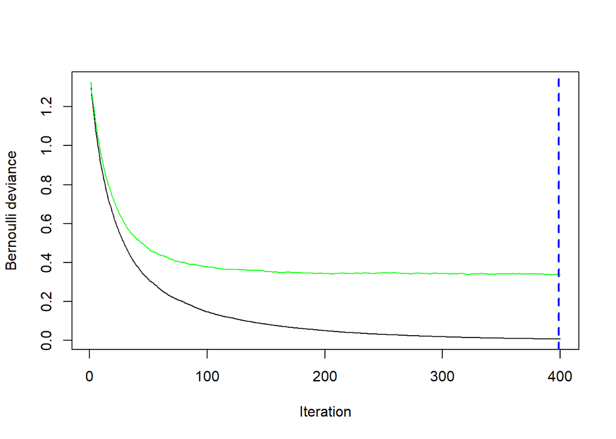

```r
print(nTrees)
```

```
## [1] 399
```

Probably, the most useful methods of all (as usual) is the summary.  
Function `summary()` shows relative importance of variables.  
Add vector of cumulative sums of importance index, plot cumulative sums, see which variables were most important.

```r
relImport<-summary(modelGBM)
relImport$cumSum<-cumsum(summary(modelGBM)$rel.inf)
```

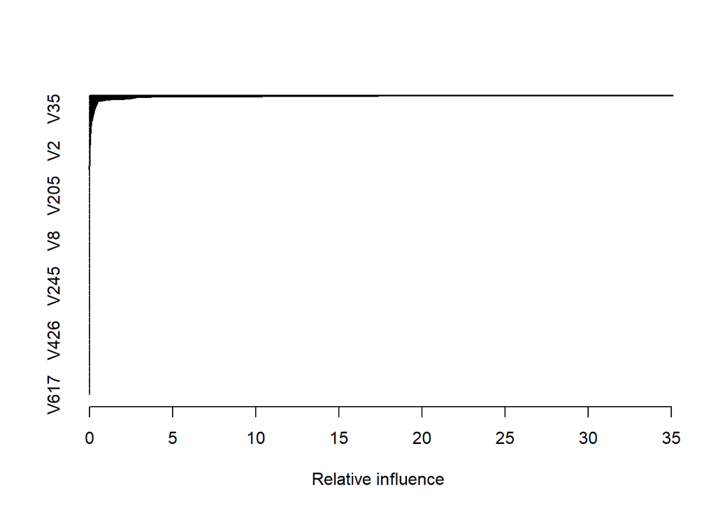

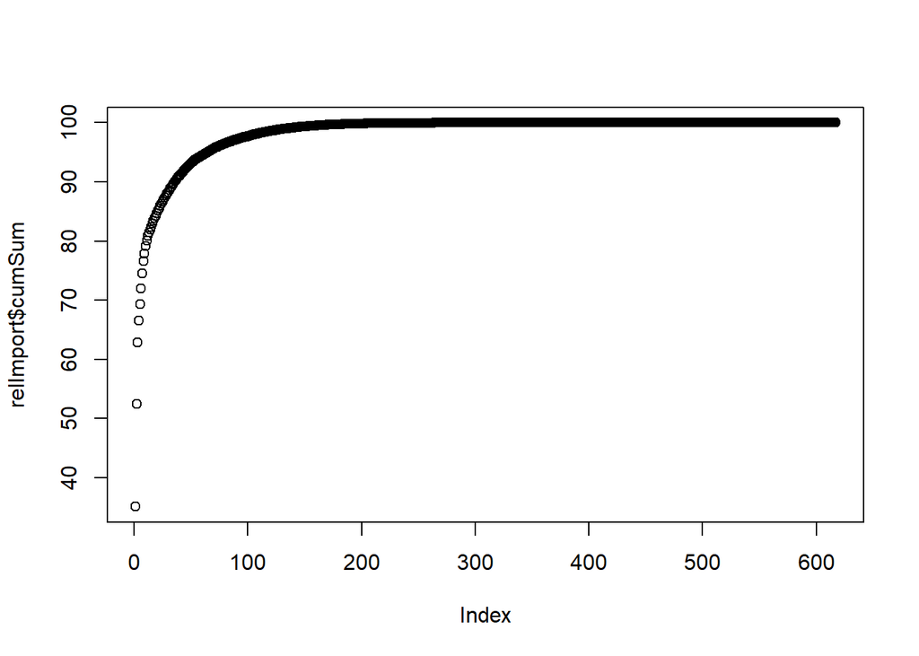

```r
plot(relImport$cumSum)
```

```r
head(relImport,50)
```

```
##       var    rel.inf   cumSum
## V298 V298 35.0921774 35.09218
## V297 V297 17.3837351 52.47591
## V106 V106 10.3813780 62.85729
## V201 V201  3.6908046 66.54809
## V107 V107  2.8025174 69.35061
## V138 V138  2.6506175 72.00123
## V295 V295  2.4697351 74.47097
## V137 V137  2.0847295 76.55569
## V170 V170  1.3630402 77.91873
## V294 V294  1.2636985 79.18243
## V117 V117  0.9246569 80.10709
## V171 V171  0.7828251 80.88992
## V52   V52  0.5528802 81.44280
## V398 V398  0.5005170 81.94331
## V133 V133  0.4828409 82.42615
## V486 V486  0.4782546 82.90441
## V76   V76  0.4732746 83.37768
## V202 V202  0.4492788 83.82696
## V293 V293  0.4409607 84.26792
## V167 V167  0.4363975 84.70432
## V439 V439  0.4151807 85.11950
## V303 V303  0.4079157 85.52742
## V613 V613  0.3781124 85.90553
## V169 V169  0.3752089 86.28074
## V289 V289  0.3664634 86.64720
## V176 V176  0.3450153 86.99222
## V590 V590  0.3408162 87.33303
## V35   V35  0.3314550 87.66449
## V233 V233  0.3264354 87.99092
## V113 V113  0.3240004 88.31492
## V407 V407  0.3121429 88.62707
## V165 V165  0.3078889 88.93495
## V105 V105  0.3012612 89.23622
## V139 V139  0.2898269 89.52604
## V166 V166  0.2878985 89.81394
## V400 V400  0.2862534 90.10019
## V258 V258  0.2574592 90.35765
## V474 V474  0.2523333 90.60999
## V162 V162  0.2521916 90.86218
## V212 V212  0.2295111 91.09169
## V182 V182  0.2261641 91.31785
## V574 V574  0.2159784 91.53383
## V516 V516  0.2157533 91.74959
## V116 V116  0.2149919 91.96458
## V404 V404  0.2142390 92.17882
## V219 V219  0.2077885 92.38661
## V305 V305  0.2023491 92.58895
## V575 V575  0.1896074 92.77856
## V614 V614  0.1880965 92.96666
## V178 V178  0.1835602 93.15022
```

Method `predict()` returns log odds or probabilities of classes.

```r
d$modelGBM <- predict(modelGBM,newdata=d,type='response',
                      n.trees=nTrees)
head(predict(modelGBM))
```

```
## Using 399 trees...
```

```
## [1] -6.063734 -6.277008  9.667543  5.265418 -4.998404 -8.074243
```

```r
showPred<-cbind(Response=d$isLetter*1,Predict=d$modelGBM)
showPred[order(d$isLetter*1),][1:10,]
```

```
##       Response      Predict
##  [1,]        0 0.0023203046
##  [2,]        0 0.0018754897
##  [3,]        0 0.0067034685
##  [4,]        0 0.0003113618
##  [5,]        0 0.0006528704
##  [6,]        0 0.0150889820
##  [7,]        0 0.0037669160
##  [8,]        0 0.0004386754
##  [9,]        0 0.0002507949
## [10,]        0 0.0001554666
```

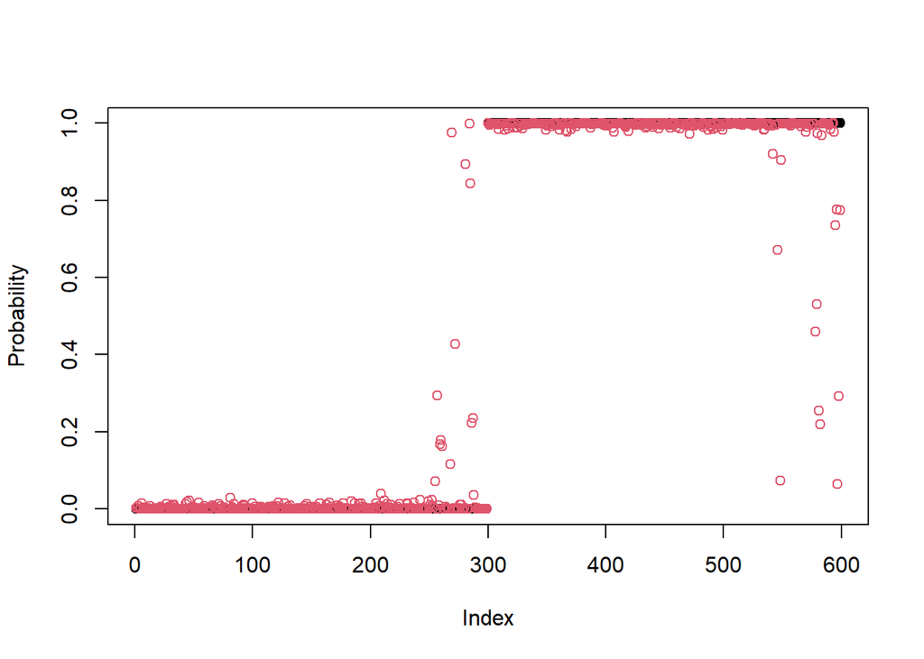

```r
matplot(1:length(showPred[,1]),showPred[order(d$isLetter*1),],pch=1,ylab="Probability",xlab="Index")
```